# Part II - (Loan Data from Prosper)

## by (Henry Ugochukwu Okam)

## Investigation Overview

- The goal of our investigation is to gather key insights from the loan data using appropriate visualizations. These visualization should help to answer the following research questions for the main variables of interest:
1. What factors affect a loan's outcome status?
2. What factors affects the borrower's APR or interest rate?
3. To identify if there are differences between loans depending on how large the original loan amount was.

## Dataset Overview

This data set contains the customer's data from a fictional loan company known as **Prosper**. This dataset comprises of 113,937 loans with 81 variables on each loan, including loan amount, borrower rate (or interest rate), current loan status, borrower income, and many others. Out of these 81 variables, the analysis was focused on just 17 variables of interest to help with answering the research questions. A new dataset with the variables of interest was created with a structure of 106312 observations and 17 features which included nine categorical variables and eight quantitative variables.

## Distribution of Loan Status

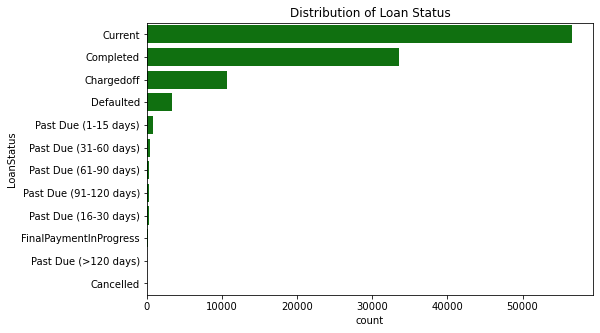

## Effect of MonthlyLoanPayment & LoanOriginalAmount on LoanStatus

Across all the loan status categories, it is observed that the higher the loan original amount obtained, the higher the monthly loan payments signifying a positive correlation between MonthlyLoanPayment and LoanOrginalAmount across the different LoanStatus categories

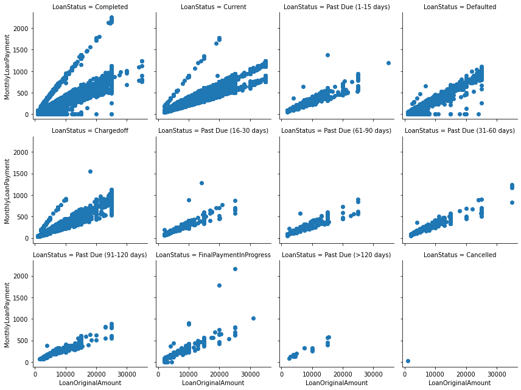

## Effect of Term, LoanMonth & LoanYear on Loan Original Amount

- It was observed that larger loan original amounts of `$12,000` and above would likely have a 60 month loan Term , while loan amounts of `$7,500` on average would have a 36 month Term, with lesser amounts of `$5,000` and below having a 12 month loan Term period to run.
- Also, the progression of loans obtained across months of the year shows that higher loan amounts are gotten by borrowers in January and December than in other periods of the year, with June been the month with the lowest loan amounts given out on average.
- It is noticeable that 2013 had a high rate of processed loans at Prosper while 2009 saw a high decline in loans given out by Prosper. In Q1 of 2009, no loans were isuued which may be attributed to the company - Prosper been shut down within the period due to certain reasons. Loans only started being issued in Q2 of 2009 and rose steadily till Q4 same year.

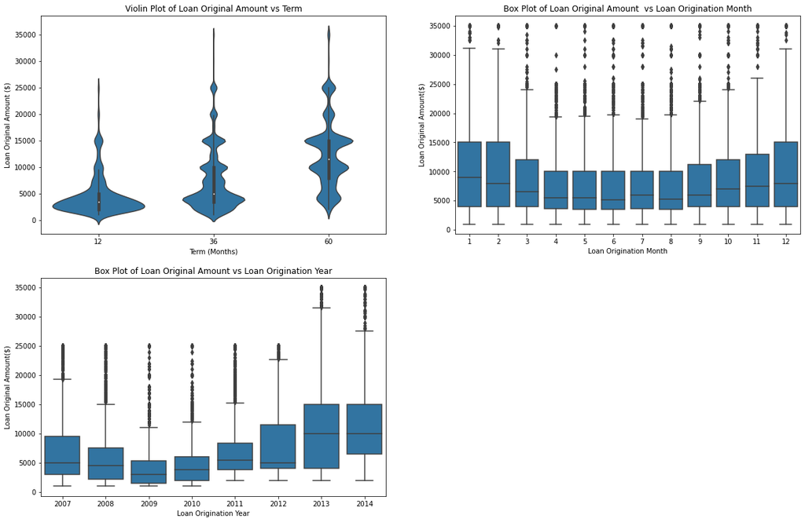

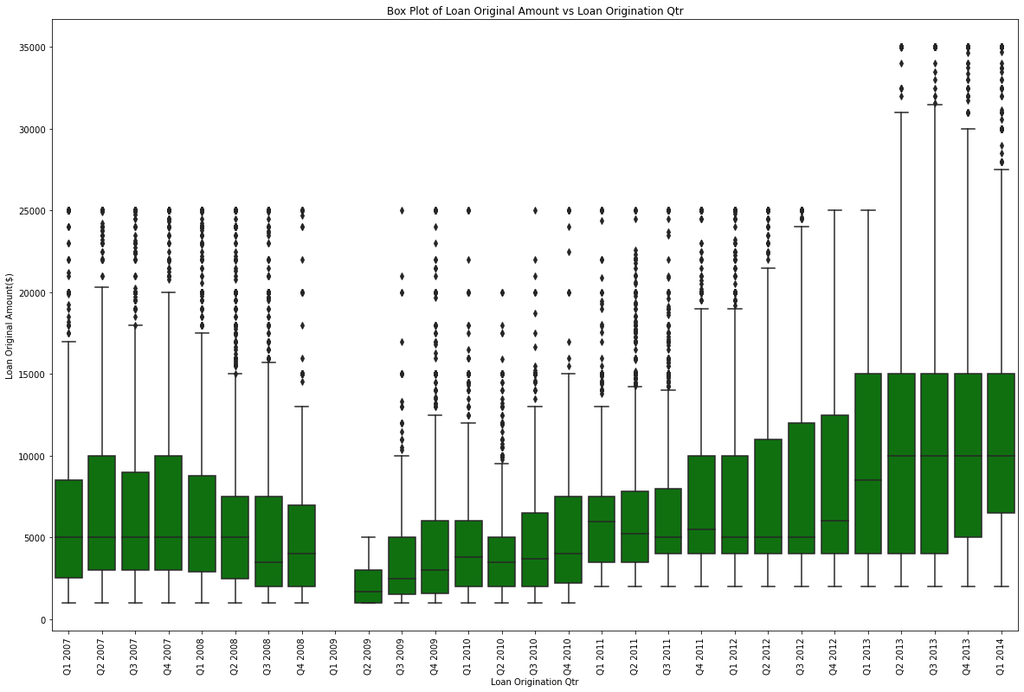

## Relationship btw Loan Original Amount, Borrower APR & Term

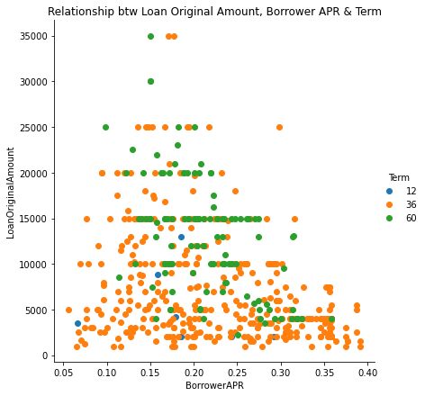

## Effect of Income Range & Employment Status on LoanOriginal Amount

- Not employed borrowers and borrowers with an income range of `$0` as at the time of loan listing had considerable access to loans. Middle income earners of `$25k-$49.9k` have access to same sizes of loans with `$0` income earners. Lower income earners between the range of `$1-$25,000` had access to the smallest size of loans which is likely to be because of their low earning capacity, while high income earners of *50K-100k+* got access to larger sizes of loans for obvious reasons.
- In regards of employment status, it is quite related with the income range as employed borrowers accessed higher sizes of loans while part-time and not employed borrowers accessed the smallest sizes of loans. This is expected as the loan company would very likely give more loans to those with a fixed income (employed) compared to those without a fixed income.

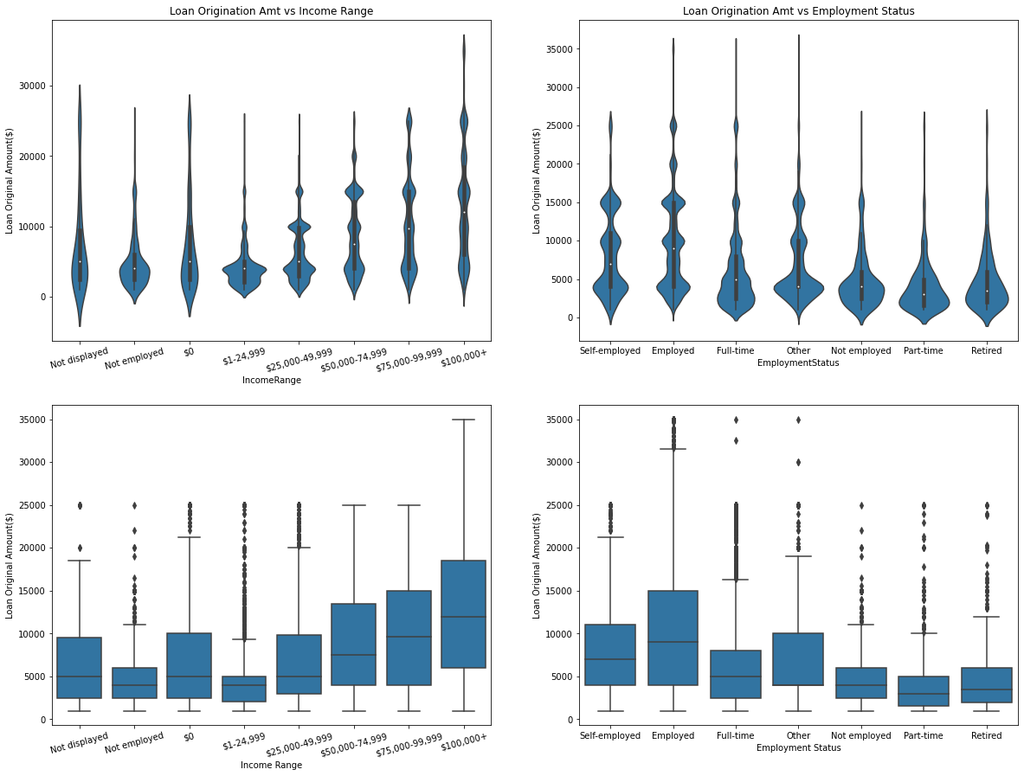